# Reconstrução reticulada de áreas ancestrais (*Dispersal-Extinction Cladogenesis model*)

José Ricardo Inacio Ribeiro

Isso é um [R Markdown](http://rmarkdown.rstudio.com) Notebook depositado no [Bioforum](http://bioforum.wordpress.com). Quando executar o código, os resultados aparecerão abaixo dele!

# Agora, vamos implementar um modelo mais complexo. Vamos inserir eventos anagenéticos de dispersão e extinção no modelo.

```r
## Biogeografia paramétrica:
library(ape)
library(phangorn)
library(phytools)
```

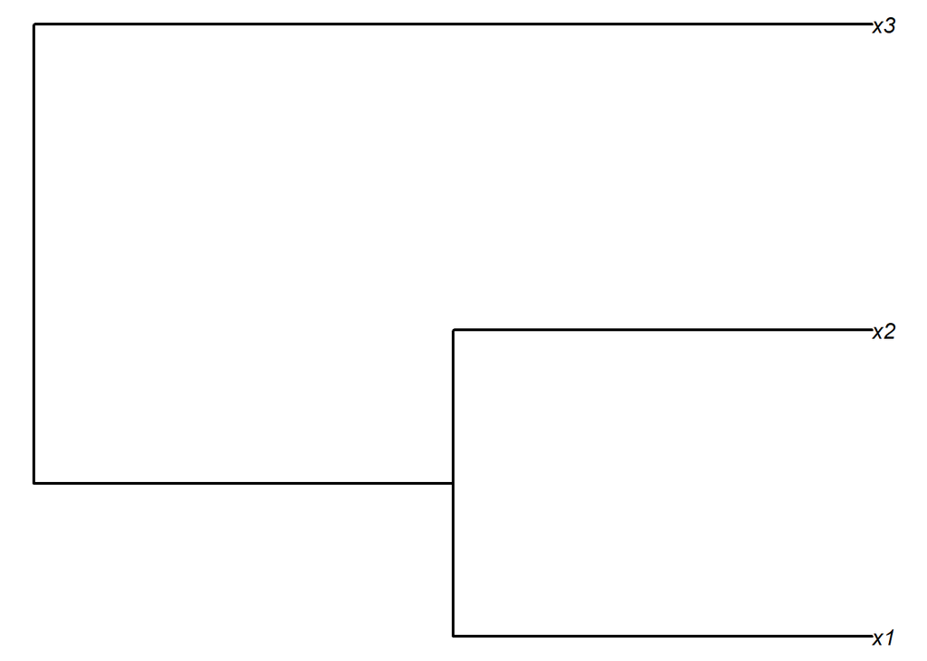

```r
library(geiger)
#library(gtools)

## ler árvore de uma string:
texto.arv <- ('((x1:0.5, x2:0.5):0);')
texto.arv <- ('((x1:10, x2:10):10, x3:20);')
arv1 <- read.tree(text = texto.arv)
plot(arv1, no.margin = TRUE, edge.width = 2)
```

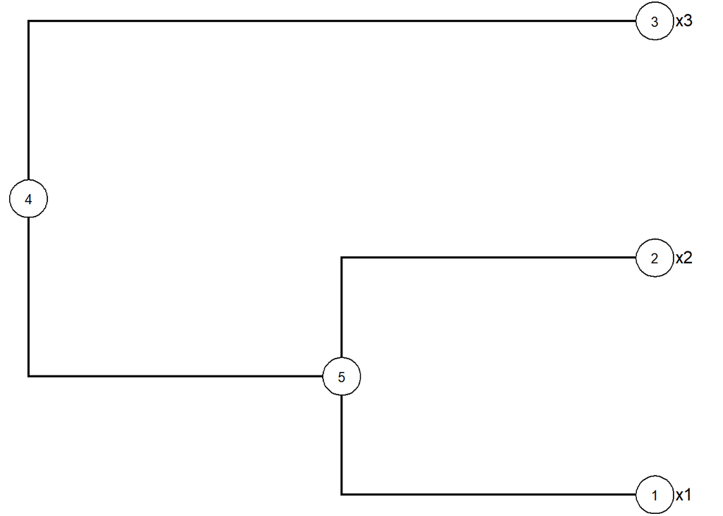

```r
# vamos ver os nós:
#plotaremos com os nós terminais e nós internos x4 e x5:
plotTree(arv1, offset = 1, type="phylogram")

labelnodes(1:(Ntip(arv1) + arv1$Nnode),
           1:(Ntip(arv1) + arv1$Nnode),
           interactive = F,cex = 0.8)
```

### Implementei uma função alterada que leva em consideração os processos de anagênese, chamada *ZECA.biogeo_DEC*, para três *ranges* A, B e AB.

```r
# n.range = número de letras usadas
# n.areas = número máximo de ranges nos nós
ZECA.biogeo.DEC <- function(ranges, n.range, n.areas, arvore, x.D, x.E){
  arv <- arvore
  # áreas A, B e C e a matriz de transição Q (forma analítica):
  #x.D <- taxaD
  #x.E <- taxaE


  Parea <- 1 / (2^n.range - 1) # priori de cada área (pi)
  priori <- matrix(c(Parea, 0, 0,
                     0, Parea, 0,
                     0, 0, Parea), nc = 3, byrow = T)

  #Cladogênese (sem o parâmetro j):
  cladogen <- matrix(c(1/3, 0, 1/18,
                       0, 1/3, 1/18,
                       1/18, 1/18, 1/18), byrow = T, ncol = 3)
  colnames(cladogen) <- rownames(cladogen) <- c('A', 'B', 'AB')


  arranjo <- t(combn(c(LETTERS[1:n.range]), n.areas))
  for(j in 1:dim(arranjo)[1]){
    for(i in 1:n.range){
      if (all(ranges == LETTERS[i])){
        letras <- which(LETTERS[1:n.range] != LETTERS[i])
        ranges[length(ranges) + 1] <- paste0(arranjo[j,], collapse = '')
        ranges[length(ranges) + 1] <- LETTERS[letras]
      }
    }
    if (any(ranges != LETTERS[1])){
      ranges[length(ranges) + 1] <- paste0(arranjo[j,], collapse = '')
    }
    if (all(ranges == paste0(arranjo[j,], collapse = ''))){
      ranges <- c(ranges, LETTERS[1:n.range])
    }
  }


  tras <- matrix(c(NA, 0, x.D, 0, NA, x.D, x.E, x.E, NA),
                 byrow = TRUE, ncol = 3)
  #trans.sup <- upper.tri(trans, diag = FALSE) * x.D
  #trans.inf <- lower.tri(trans, diag = FALSE) * x.E
  #trans <- trans.sup + trans.inf
  diag(tras) <- -rowSums(tras, na.rm = T)

  names(ranges) <- c(arv$tip.label, ranges[(length(arv$tip.label) + 1):length(ranges)])

  if (!is.factor(ranges)) {
    ranges <- factor(ranges)
  }
  x <- reorder(x = as.factor(ranges), X = c(1:length(ranges)))
  nll <- nlevels(x)
  cores <- palette()
  cor <- cores[as.integer(x)]
  cols <- setNames(cor, x)
  ARE <- to.matrix(ranges, x)
  ARE <- ARE[-c(dim(ARE)[1]:length(arv$tip.label) + 1),]

  ##################################
  # algoritmo para cálculo de verossimilhanças:

  lvls <- levels(x)
  x <- as.integer(x)

  rate <- tras #coeficientes da matriz de transição

  #likelihood
  nb.tip <- length(arv$tip.label)

  if(any(arvore$edge.length == 0)){
    nb.node <- arv$Nnode - 1
  } else{
    nb.node <- arv$Nnode
  }

  liks <- matrix(0, nb.tip + nb.node, nll) # matriz que irá possuir as probabilidades marginais condicionais
  veros <- matrix(0, nb.tip + nb.node, nll) # matriz que irá possuir as verossimilhanças fracionadas
  # priors <- matrix(0, nb.tip + nb.node, nll) # suposta matriz de prioris de áreas em um nó

  TIPS <- 1:nb.tip

  liks[cbind(TIPS, x[1:nb.tip])] <- 1
  # priors[cbind(TIPS, x[1:nb.tip])] <- 1

  #caso não haja estado no terminal
  if (anyNA(ranges)) {
    liks[which(is.na(x)), ] <- 1
    # priors[which(is.na(x)), ] <- 1
  }

  arv <- reorder(arv, "postorder") #reordenando os levels

  e1 <- arv$edge[, 1]
  e2 <- arv$edge[, 2]
  EL <- arv$edge.length
  # e1 #nós internos
  # e2 #nós terminais e raiz
  # EL #ramos

  # optamos pela decomposição espectral (uma forma analítica):
  comp <- numeric(nb.tip + nb.node)
  Q <- tras #matriz de transição de ranges
  decompo <- eigen(Q)
  lambda <- decompo$values
  GAMMA <- decompo$vectors
  invGAMMA <- solve(GAMMA)

  #para a área
  for (i in seq(from = 1, by = 2, length.out = nb.node)) {
    j <- i + 1L
    if(any(arvore$edge.length == 0)){
      anc <- e1[i] - 1
    } else {
      anc <- e1[i]
    }

    des1 <- e2[i]
    des2 <- e2[j]

    #prioris = estimando-se as probabilidades da evolução dos
    #ranges ancestral - descendente (anagênese):

    dQi <- GAMMA %*% diag(exp(lambda * EL[i])) %*% invGAMMA
    # p.anai <- priori %*% dQi * liks[des1,] #prioris para a dispersão e extinção

    dQj <- GAMMA %*% diag(exp(lambda * EL[j])) %*% invGAMMA
    # p.anaj <- priori %*% dQj * liks[des2,] #prioris para a dispersão e extinção

    #probabilidades de cada range
    # prioriT_i <- priori %*% cladogen %*% dQi
    prioriT <- priori %*% cladogen * 1
    # prioriT_j <- priori %*% cladogen %*% dQj

    # Verossimilhanças condicionais dos processos de anagênese e da cladogênese
    v.l <-  liks[des1,] %*% dQi %*% prioriT
    # v.l <-  liks[des1,] %*% p.anai %*% prioriT_i
    v.r <-  liks[des2,] %*% dQj %*% prioriT

    v <- v.l * v.r # verossimilhança do cenário: L(nodes)

    veros[anc,] <- v

    comp[anc] <- sum(v)
    liks[anc, ] <- v / comp[anc]
  }
  #UFA! As reconstruções marginais rapidinhas!
  x <- reorder(x = as.factor(ranges), X = c(1:length(ranges)))
  colnames(liks) <- levels(x)

  colnames(veros) <- levels(x)


  #forma matricial:
  vero.total <- veros[anc,] %*% prioriT
  vero.total <- sum(vero.total) # verossimilhança do modelo
  #log(vero.total) #em log na base e
  #################################################
  # RECONSTRUÇÃO:
  plotTree(arv, type = "phylogram", fsize = 0.7, ftype = "i",lwd = 1, offset = 2)

  if(any(arvore$edge.length == 0)){
    nodelabels(node = 1:(arv$Nnode - 1) + Ntip(arv) + 1,
             pie = liks[1:(arv$Nnode - 1) + Ntip(arv),],
             piecol = c('black', '#61D04F', '#DF536B'), cex = 0.8)
  } else {
    nodelabels(node = 1:arv$Nnode + Ntip(arv),
             pie = liks[1:arv$Nnode + Ntip(arv),],
             piecol = unique(cols), cex = 0.8)
  }
  ARE <- to.matrix(ranges, levels(x))
  legend(x = "bottomleft", legend = unique(x),
         pch = 19, col = unique(cols), bty = 'o',
         pt.cex = 1.5)
  tiplabels(pie = ARE[arv$tip.label,], piecol = unique(cols),
            cex = 0.5)
  #######################
  probMar <- liks[-TIPS,]

  if(all(arvore$edge.length != 0)){
    rownames(probMar) <- c(anc, anc + 1)
  }

  verosCond <- veros[-TIPS,]
  if(all(arvore$edge.length != 0)){
    rownames(verosCond) <- c(anc, anc + 1)
  }

  return(list(prob.marginal = probMar, vero_fracionada = verosCond, log_vero = log(vero.total)))
}
```

### Vamos comparar alguns modelos já conhecidos nossos?

#### $\color{blue}{\text{Condição geral: a taxa total é baixa. Modelo 1: $D < E$}}$

```r
# the overall rate is low
# D < E
mod1 <- ZECA.biogeo.DEC(ranges = c('A', 'B', 'B'), n.range = 2, n.areas = 2, arvore = arv1,
                        x.D = 0.001, x.E = 0.009)
```

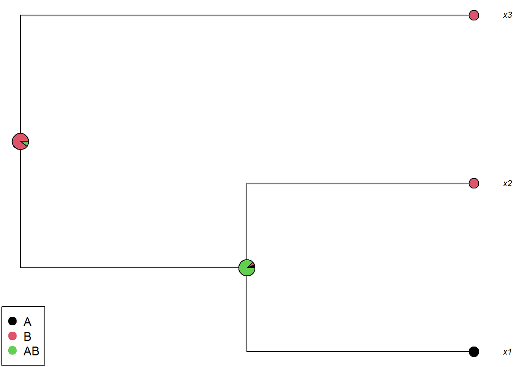

```r
mod1 #k = 2 parâmetros livres (2^n - 2, com n = 2)
```

```
## $prob.marginal
##             A          B         AB
## 4 0.003966072 0.89675581 0.09927812
## 5 0.060829314 0.06082931 0.87834137
##
## $vero_fracionada
##              A            B           AB
## 4 1.369997e-05 3.097656e-03 0.0003429355
## 5 2.374992e-05 2.374992e-05 0.0003429355
##
## $log_vero
## [1] -7.769615
```

#### $\color{blue}{\text{modelo 2: $D = E$}}$

```r
# D = E
mod2 <- ZECA.biogeo.DEC(ranges = c('A', 'B', 'B'), n.range = 2, n.areas = 2, arvore = arv1,
                        x.D = 0.005, x.E = 0.005)
```

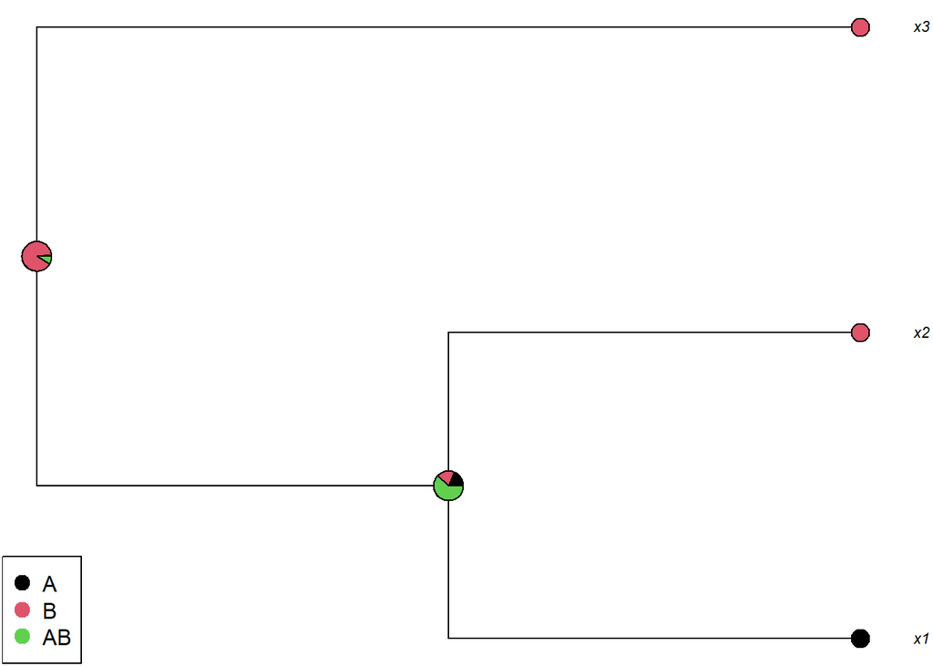

```r
mod2 #k = 2 parâmetros livres
```

```
## $prob.marginal
##            A         B         AB
## 4 0.01818511 0.8942056 0.08760933
## 5 0.19056280 0.1905628 0.61887440
##
## $vero_fracionada
##              A            B           AB
## 4 7.118329e-05 0.0035002534 0.0003429355
## 5 1.055962e-04 0.0001055962 0.0003429355
##
## $log_vero
## [1] -7.637533
```

#### $\color{blue}{\text{modelo 3: $D > E$}}$

```r
# D > E
mod3 <- ZECA.biogeo.DEC(ranges = c('A', 'B', 'B'), n.range = 2, n.areas = 2, arvore = arv1,
                        x.D = 0.009, x.E = 0.001)
```

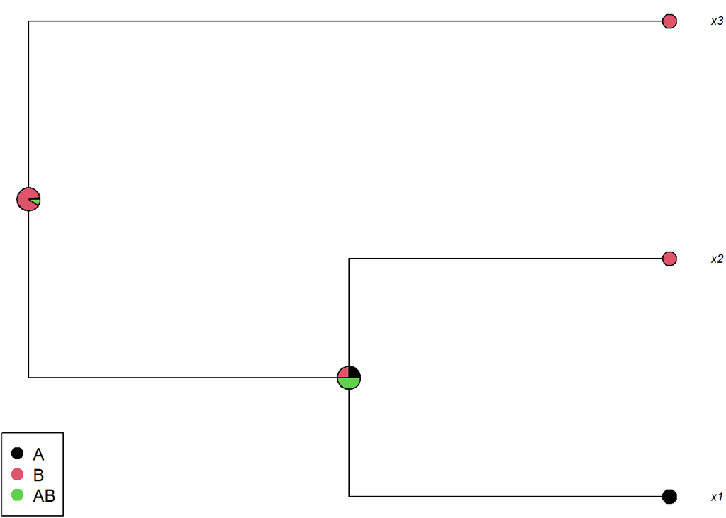

```r
mod3 #k = 2 parâmetros livres
```

```
## $prob.marginal
##            A         B        AB
## 4 0.02912014 0.8823741 0.0885058
## 5 0.24719462 0.2471946 0.5056108
##
## $vero_fracionada
##              A            B           AB
## 4 0.0001128325 0.0034189558 0.0003429355
## 5 0.0001676622 0.0001676622 0.0003429355
##
## $log_vero
## [1] -7.648253
```

```r
# the overall rate is high
# D < E
mod11 <- ZECA.biogeo.DEC(ranges = c('A', 'B', 'B'), n.range = 2, n.areas = 2, arvore = arv1,
                        x.D = 0.01, x.E = 0.09)
```

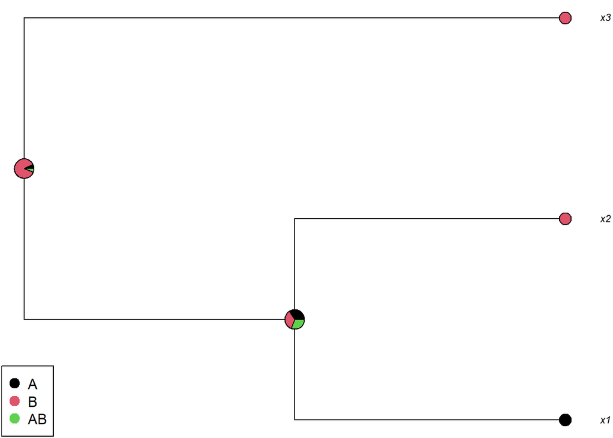

```r
mod11 #k = 2 parâmetros livres (2^n - 2, com n = 2)
```

```
## $prob.marginal
##            A         B         AB
## 4 0.07170083 0.8705725 0.05772671
## 5 0.34397646 0.3439765 0.31204708
##
## $vero_fracionada
##              A            B           AB
## 4 0.0004259512 0.0051717863 0.0003429355
## 5 0.0003780255 0.0003780255 0.0003429355
##
## $log_vero
## [1] -7.20255
```

```r
# D = E
mod22 <- ZECA.biogeo.DEC(ranges = c('A', 'B', 'B'), n.range = 2, n.areas = 2, arvore = arv1,
                        x.D = 0.05, x.E = 0.05)
```

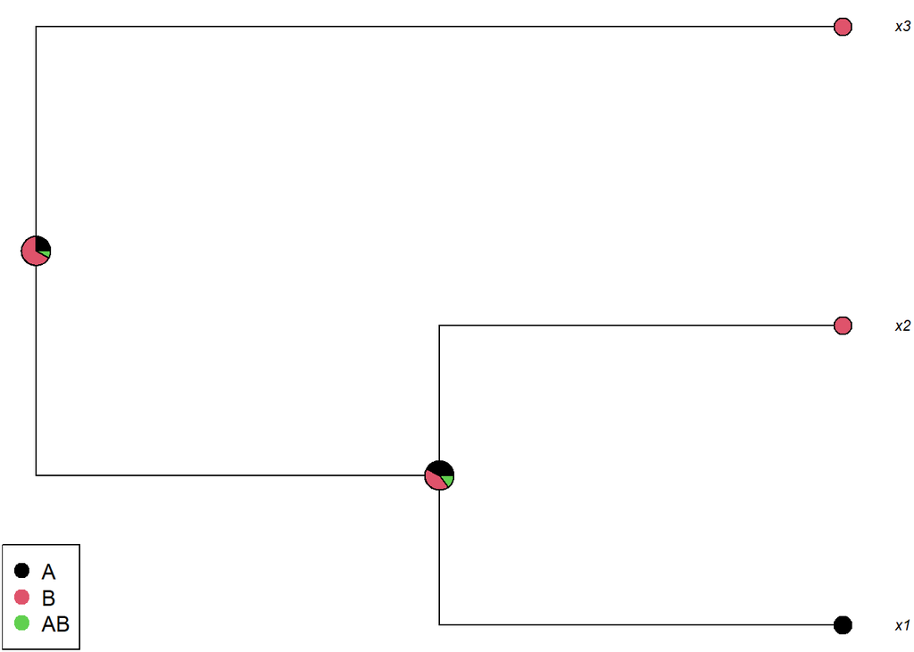

```r
mod22 #k = 2 parâmetros livres
```

```
## $prob.marginal
##           A         B         AB
## 4 0.2453614 0.6742048 0.08043386
## 5 0.4253696 0.4253696 0.14926087
##
## $vero_fracionada
##              A            B           AB
## 4 0.0010461158 0.0028745202 0.0003429355
## 5 0.0009773113 0.0009773113 0.0003429355
##
## $log_vero
## [1] -7.547774
```

```r
# D > E
mod33 <- ZECA.biogeo.DEC(ranges = c('A', 'B', 'B'), n.range = 2, n.areas = 2, arvore = arv1,
                        x.D = 0.09, x.E = 0.01)
```

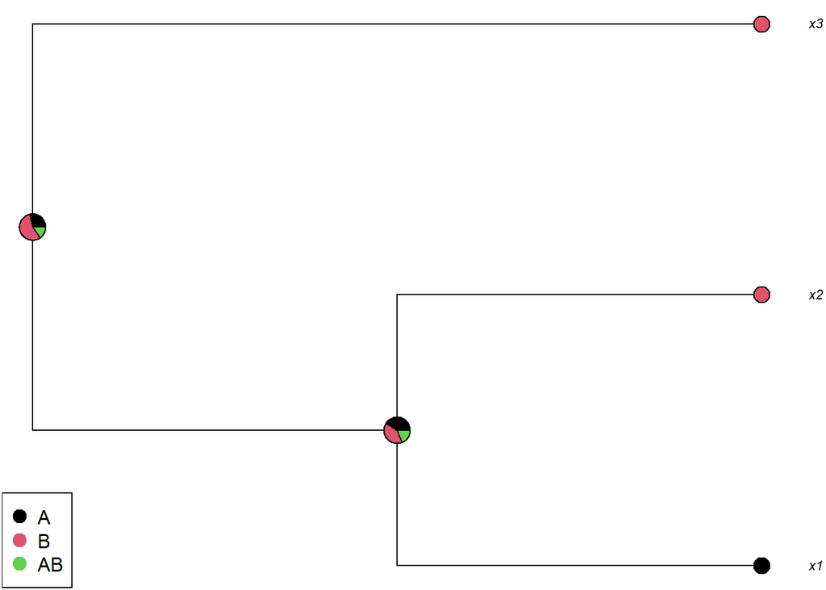

```r
mod33 #k = 2 parâmetros livres
```

```
## $prob.marginal
##           A         B        AB
## 4 0.2873506 0.5590167 0.1536327
## 5 0.4058044 0.4058044 0.1883913
##
## $vero_fracionada
##              A            B           AB
## 4 0.0006414175 0.0012478245 0.0003429355
## 5 0.0007387005 0.0007387005 0.0003429355
##
## $log_vero
## [1] -8.239737
```

#### “*Model behavior is data-dependent, there is not ‘one’ behavior!*”

(MASSANA *et al.*, 2015)

### Avaliando-se os modelos com *log-likelihood ratio test*:

**Lembrando que o número de parâmetros livres, *k*, é igual a: $k = 2$**

```r
############# Avaliação dos modelos ##############
# Vamos comparar modelos que são aninhados (likelihood-ratio tests).
modelos<-c("mod1", "mod2", "mod3", "mod22", "mod33")
graus <- c(2, 2, 2, 2, 2, 2)
LR.test<-matrix(NA, 5, 3, dimnames = list(paste(modelos, "-vs-mod11", sep = ""),
                                     c("LR", "df", "P(X2)")))
allfits<-list(mod1$log_vero, mod2$log_vero, mod3$log_vero,
              mod22$log_vero, mod33$log_vero, mod11$log_vero)

for(i in 2:length(allfits) - 1){
  LR.test[i, 1] <- - 2 * (allfits[[i]] - allfits[[6]])
  LR.test[i, 2] <- graus[i] - graus[6]
  LR.test[i, 3]<-pchisq(LR.test[i, 1], df = LR.test[i, 2],
                       lower.tail = FALSE)
}
LR.test
```

```
##                       LR df P(X2)
## mod1-vs-mod11  1.1341304  0     0
## mod2-vs-mod11  0.8699670  0     0
## mod3-vs-mod11  0.8914070  0     0
## mod22-vs-mod11 0.6904484  0     0
## mod33-vs-mod11 2.0743740  0     0
```

-Isso significa que a variação na taxa de extinção ou na taxa de dispersão pode melhorar ou piorar o ajuste dos dados!

### Avaliando-se os modelos com *$AIC$, $AIC_c$ e $BIC$*, estatísticas que não partem da premissa que os modelos *devam ser aninhados*…

```r
# Valor de AIC (e os pesos de AKAIKE) do nossos modelos ajustados e
# não aninhados:
modelos <- c('mod1', 'mod2', 'mod3', 'mod11', 'mod22', 'mod33')
k <- c(2, 2, 2, 2, 2, 2)
n <- 1 # número de caracteres (Butler and King, 2004)
stats.test<-matrix(NA, 6, 12, dimnames = list(paste(modelos), c("LR", "df", "P(X2)",
                    "AIC", "d.AIC", "wAIC", "AICc","d.AICc", "wAICc", "BIC","d.BIC",
                    "wBIC")))

AIC.val1 <- -2 * mod1$log_vero + (2 * k[1]) #AIC
AIC.val2 <- -2 * mod2$log_vero + (2 * k[2]) #AIC
AIC.val3 <- -2 * mod3$log_vero + (2 * k[3]) #AIC
AIC.val11 <- -2 * mod11$log_vero + (2 * k[4]) #AIC
AIC.val22 <- -2 * mod22$log_vero + (2 * k[5]) #AIC
AIC.val33 <- -2 * mod33$log_vero + (2 * k[6]) #AIC


AIC.valores <- c(AIC.val1, AIC.val2, AIC.val3, AIC.val11, AIC.val22, AIC.val33)
round(AIC.valores, 3)
```

```
## [1] 19.539 19.275 19.297 18.405 19.096 20.479
```

```r
# AICc:
AICc.val1 <- AIC.val1 * (n / (n - k[1] - 1))
AICc.val2 <- AIC.val2 * (n / (n - k[2] - 1))
AICc.val3 <- AIC.val3 * (n / (n - k[3] - 1))
AICc.val11 <- AIC.val11 * (n / (n - k[4] - 1))
AICc.val22 <- AIC.val22 * (n / (n - k[5] - 1))
AICc.val33 <- AIC.val33 * (n / (n - k[6] - 1))

AICc.valores <- c(AICc.val1, AICc.val2, AICc.val3, AICc.val11, AICc.val22, AICc.val33)
round(AICc.valores, 3)
```

```
## [1]  -9.770  -9.638  -9.648  -9.203  -9.548 -10.240
```

```r
# Valores de BIC (Bayesian Information Criterion):
BIC.val1 <- -2 * mod1$log_vero + (k[1] * log(n))
BIC.val2 <- -2 * mod2$log_vero + (k[2] * log(n))
BIC.val3 <- -2 * mod3$log_vero + (k[3] * log(n))
BIC.val11 <- -2 * mod11$log_vero + (k[4] * log(n))
BIC.val22 <- -2 * mod22$log_vero + (k[5] * log(n))
BIC.val33 <- -2 * mod33$log_vero + (k[6] * log(n))

BIC.valores <- c(BIC.val1, BIC.val2, BIC.val3, BIC.val11, BIC.val22, BIC.val33)
round(BIC.valores, 3)
```

```
## [1] 15.539 15.275 15.297 14.405 15.096 16.479
```

```r
w.aic <- 0
delta.aic <- 0
w.aicc <- 0
delta.aicc <- 0
w.bic <- 0
delta.bic <- 0


for(i in 1:length(k)){
  delta.aic[i] <- AIC.valores[i] - min(AIC.valores)
  delta.aicc[i] <- AICc.valores[i] - min(AICc.valores)
  delta.bic[i] <- BIC.valores[i] - min(BIC.valores)
}
w.aic<- (exp(- delta.aic / 2)) / (exp( - delta.aic[1] / 2) +
                exp( - delta.aic[2] / 2) + exp( - delta.aic[3] / 2))
w.aicc<- (exp(- delta.aicc / 2)) / (exp( - delta.aicc[1] / 2) +
                exp( - delta.aicc[2] / 2) + exp( - delta.aicc[3] / 2))
w.bic<- (exp(- delta.bic / 2)) / (exp( - delta.bic[1] / 2) +
                exp( - delta.bic[2] / 2) + exp( - delta.bic[3] / 2))

stats.test[,4] <- round(AIC.valores, 3)
stats.test[,5] <- round(delta.aic, 3)
stats.test[,6] <- round(w.aic, 3)
stats.test[,1] <- c(round(as.numeric(LR.test[1:3,1]), 3), '-', round(as.numeric(LR.test[4:5,1]), 3))
stats.test[,2] <- c(round(as.numeric(LR.test[1:3, 2]), 3), '-', round(as.numeric(LR.test[4:5, 2]), 3))
stats.test[,3] <- c(round(as.numeric(LR.test[1:3, 3]), 3), '-', round(as.numeric(LR.test[4:5, 3]), 3))

stats.test[,7] <- round(AICc.valores, 3)
stats.test[,8] <- round(delta.aicc, 3)
stats.test[,9] <- round(w.aicc, 3)

stats.test[,10] <- round(BIC.valores, 3)
stats.test[,11] <- round(delta.bic, 3)
stats.test[,12] <- round(w.bic, 3)

stats.test <- as.data.frame(stats.test) #resultados
stats.test
```

|  | LR | df | P(X2) | AIC | d.AIC | wAIC | AICc | d.AICc | wAICc | BIC | d.BIC | wBIC |
| --- | --- | --- | --- | --- | --- | --- | --- | --- | --- | --- | --- | --- |
| mod1 | 1.134 | 0 | 0 | 19.539 | 1.134 | 0.306 | -9.77 | 0.47 | 0.348 | 15.539 | 1.134 | 0.306 |
| mod2 | 0.87 | 0 | 0 | 19.275 | 0.87 | 0.349 | -9.638 | 0.602 | 0.325 | 15.275 | 0.87 | 0.349 |
| mod3 | 0.891 | 0 | 0 | 19.297 | 0.891 | 0.345 | -9.648 | 0.591 | 0.327 | 15.297 | 0.891 | 0.345 |
| mod11 | - | - | - | 18.405 | 0 | 0.539 | -9.203 | 1.037 | 0.262 | 14.405 | 0 | 0.539 |
| mod22 | 0.69 | 0 | 0 | 19.096 | 0.69 | 0.382 | -9.548 | 0.692 | 0.311 | 15.096 | 0.69 | 0.382 |
| mod33 | 2.074 | 0 | 0 | 20.479 | 2.074 | 0.191 | -10.24 | 0 | 0.44 | 16.479 | 2.074 | 0.191 |

#### $\color{blue}{\text{Os resultados sugerem que o melhor modelo parece ser aquele que privilegia altas taxas de extinção: o modelo 11.}}$